# Tymewear-results

Report of Results & Figures

Author

Affiliation

Jem I Arnold

School of Kinesiology, The University of British Columbia, Vancouver, BC, Canada

Published

November 3, 2026

**Show setup code**

```r
library(targets)
library(tibble)
library(dplyr)
library(purrr)
library(ggplot2)
library(ggpubr)
library(mnirs)

theme_set(theme_mnirs())
```

**NoteMethods decisions**

- Breath-by-breath time-series synchronised with cross-correlation for each interval.
- Local outliers removed **from Parvo** with 30-sec rolling window.
- Smooth/binning method: **bin = 10** sec.
- 5-minute interval plus 60-sec recovery after end.
- Four participants (four of the six women) required shortening the strap. Visual clustering of these four participants justified omitting them from VE, but included for RR.
- Note: terminology for respiratory frequency/breathing rate is *inconsistent* throughout this document: **RR**, **BR**, or the manuscript version *f*<sub>R</sub> are used interchangeably.

## Figure 1: Descriptive plots

- Representative *Interval 4* shown for all participants.

### RR

**Show figure code**

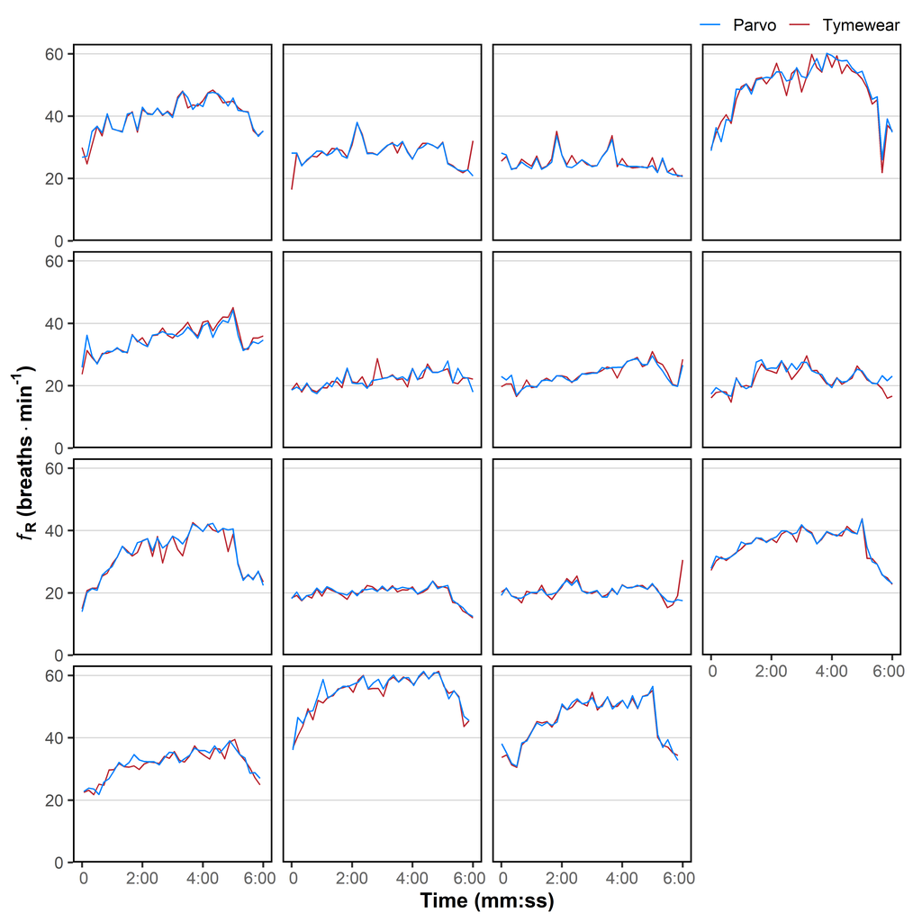

```r
tar_read(desc_RR_plot)
```

### VE

- Excluded participants highlighted in red.

**Show figure code**

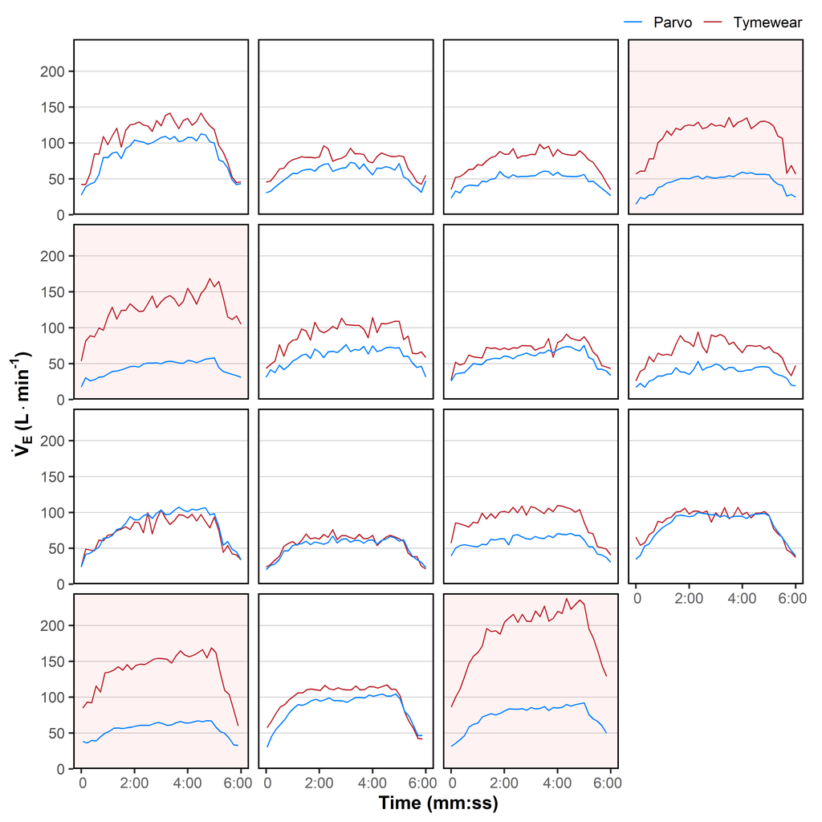

```r
tar_read(desc_VE_plot)
```

## MAE & MAPE

Obsolete, superseded by rmcorr and Bland-Altman below.

- `cv_between_devices` is the typical within-participant percentage disagreement between paired measurements.
- `cv_each_device` is the share attributable to either device, assuming both have equal and independent measurement error.
- `mean_bias` is the average percentage by which Parvo differs from Tymewear positive means Parvo is higher.

```r
list(
    "RR" = tar_read(error_summary_RR),
    "VE" = tar_read(error_summary_VE),
    "VE (ids excluded)" = tar_read(error_summary_VE_excl)
) |>
    list_rbind(names_to = "measure") |>
    knitr::kable(digits = 1)
```

| measure | n_participants | n_pairs | sd_log_difference | cv_between_devices | cv_each_device | mean_bias | MAE | MAPE |
| --- | --- | --- | --- | --- | --- | --- | --- | --- |
| RR | 15 | 2760 | 0.1 | 6.9 | 4.9 | 0.4 | 1.0 | 3.7 |
| VE | 15 | 2760 | 0.1 | 14.3 | 10.1 | -36.9 | 36.8 | 71.8 |
| VE (ids excluded) | 11 | 2030 | 0.1 | 14.0 | 9.9 | -24.1 | 19.7 | 36.7 |

## Sensitivity analysis for smoothing methods

- Four participants excluded for VE only.
- BxB (width = 1) resulting in misaligned breaths, overestimates error.
- bin = 10 sec chosen as a compromise.

**Show figure code**

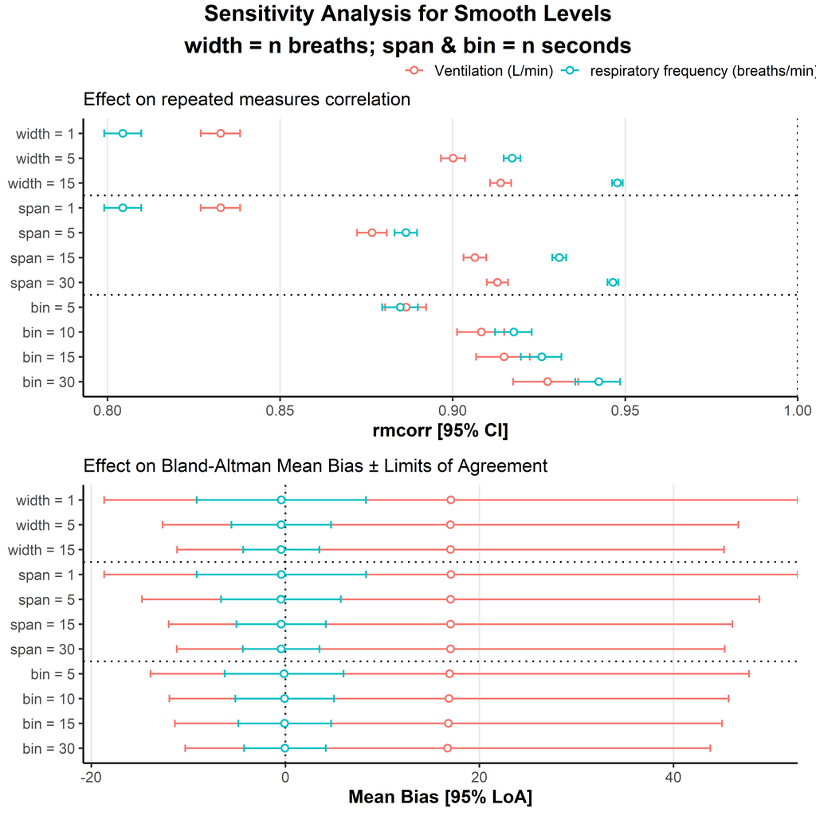

```r
exclude_ids <- c("TW04", "TW05", "BP12", "BP19")

df <- readRDS("results.rds") |>
    select(id, stage, smooth, time, br, ve, RR, VE)

df_list <- group_split(df, smooth)

yvars <- c("VE", "RR")

agree_df <- lapply(yvars, \(yvar) {
    lapply(df_list, \(.df) {
        if(yvar == "VE") .df <- filter_out(.df, id %in% exclude_ids)

        agree_table <- SimplyAgree::agreement_limit(
            .df,
            x = ifelse(yvar == "RR", "br", "ve"),
            y = ifelse(yvar == "RR", "RR", "VE"),
            id = "id",
            data_type = "nest",
            loa_calc = "blandaltman"
        )

        model <- rmcorr::rmcorr(
            participant = "id",
            measure1 = ifelse(yvar == "RR", "br", "ve"),
            measure2 = ifelse(yvar == "RR", "RR", "VE"),
            dataset = .df
        )

        tibble(
            measure = yvar,
            smooth = .df$smooth[1L],
            bias = agree_table$loa$bias,
            loa.lower = agree_table$loa$lower_loa,
            loa.upper = agree_table$loa$upper_loa,
            r = model$r,
            r.lower = model$CI[1],
            r.upper = model$CI[2],
        )
    }) |>
        list_rbind()
}) |>
    list_rbind() |>
    mutate(
        measure = factor(
            measure,
            levels = yvars,
            labels = c("Ventilation (L/min)", "respiratory frequency (breaths/min)")
        ),
        smooth = factor(
            smooth,
            levels = rev(levels(df$smooth))
        ),
    )

rmplot <- ggplot(agree_df, aes(x = smooth, colour = measure)) +
    labs(
        subtitle = "Effect on repeated measures correlation",
        x = NULL
    ) +
    theme(panel.grid.major.x = element_line()) +
    scale_colour_discrete(name = NULL) +
    coord_flip(ylim = c(NA, 1)) +
    scale_y_continuous(
        name = "rmcorr [95% CI]",
        expand = expansion(c(0.03, 0))
    ) +
    geom_hline(yintercept = 1, linetype = "dotted") +
    geom_vline(xintercept = c(4.5, 8.5), linetype = "dotted") +
    geom_errorbar(aes(ymin = r.lower, ymax = r.upper), width = 0.3) +
    geom_point(aes(y = r), fill = "white", shape = 21, stroke = 1)

baplot <- ggplot(agree_df, aes(x = smooth, colour = measure)) +
    labs(
        subtitle = "Effect on Bland-Altman Mean Bias ± Limits of Agreement",
        x = NULL
    ) +
    theme(panel.grid.major.x = element_line()) +
    scale_colour_discrete(name = NULL) +
    coord_flip() +
    scale_y_continuous(
        name = "Mean Bias [95% LoA]",
        expand = expansion(c(0.03, 0))
    ) +
    geom_hline(yintercept = 0, linetype = "dotted") +
    geom_vline(xintercept = c(4.5, 8.5), linetype = "dotted") +
    geom_errorbar(aes(ymin = loa.lower, ymax = loa.upper), width = 0.3) +
    geom_point(aes(y = bias), fill = "white", shape = 21, stroke = 1)

ggarrange(
    rmplot,
    baplot,
    nrow = 2,
    common.legend = TRUE
) |>
    annotate_figure(
        top = text_grob(
            paste(
                "Sensitivity Analysis for Smooth Levels",
                "width = n breaths; span & bin = n seconds",
                sep = "\n"
            ),
            size = 17,
            face = "bold"
        )
    )
```

## Figure 2: Repeated-measures correlation

### RR

```r
## naive correlation test
tar_read(cor_fit_RR)
```

```
#>
#>  Pearson's product-moment correlation
#>
#> data:  df[[yvar]] and df[[analysis_vars[[yvar]]$tyme]]
#> t = 326.9, df = 2758, p-value < 2.2e-16
#> alternative hypothesis: true correlation is not equal to 0
#> 95 percent confidence interval:
#>  0.9863655 0.9882454
#> sample estimates:
#>       cor
#> 0.9873401
```

```r
## ICC
tar_read(icc_fit_RR)
```

```
#>
#> Coefficient of Variation (%): 17.1 95% C.I. [12.4, 27.4]
#> Standard Error of Measurement (SEM): 5.25 95% C.I. [3.84, 8.28]
#> Standard Error of the Estimate (SEE): 0.374 95% C.I. [0.274, 0.589]
#> Standard Error of Prediction (SEP): 0.529 95% C.I. [0.387, 0.834]
#>
#> Intraclass Correlation Coefficients
#>            Model         Measures  Type    ICC Lower CI Upper CI
#> 1 one-way random        Agreement  ICC1 0.9986   0.9966   0.9994
#> 2 two-way random        Agreement  ICC2 0.9986   0.9966   0.9994
#> 3  two-way fixed      Consistency  ICC3 0.9986   0.9966   0.9994
#> 4 one-way random   Avg. Agreement ICC1k 0.9993   0.9983   0.9997
#> 5 two-way random   Avg. Agreement ICC2k 0.9993   0.9983   0.9997
#> 6  two-way fixed Avg. Consistency ICC3k 0.9993   0.9983   0.9997
```

```r
tar_read(rmcorr_fit_RR)
```

```
#>
#> Repeated measures correlation
#>
#> r
#> 0.9430812
#>
#> degrees of freedom
#> 2744
#>
#> p-value
#> 0
#>
#> 95% confidence interval
#> 0.938793 0.9470771
```

### VE

```r
## naive correlation test
tar_read(cor_fit_VE)
```

```
#>
#>  Pearson's product-moment correlation
#>
#> data:  df[[yvar]] and df[[analysis_vars[[yvar]]$tyme]]
#> t = 32.605, df = 2758, p-value < 2.2e-16
#> alternative hypothesis: true correlation is not equal to 0
#> 95 percent confidence interval:
#>  0.4999923 0.5538730
#> sample estimates:
#>       cor
#> 0.5274628
```

```r
## ICC
tar_read(icc_fit_VE)
```

```
#>
#> Coefficient of Variation (%): 33.3 95% C.I. [23.8, 56.5]
#> Standard Error of Measurement (SEM): 25.7 95% C.I. [18.8, 40.5]
#> Standard Error of the Estimate (SEE): 2.46 95% C.I. [1.8, 3.88]
#> Standard Error of Prediction (SEP): 3.48 95% C.I. [2.55, 5.5]
#>
#> Intraclass Correlation Coefficients
#>            Model         Measures  Type    ICC  Lower CI Upper CI
#> 1 one-way random        Agreement  ICC1 0.9873 0.9695870   0.9948
#> 2 two-way random        Agreement  ICC2 0.3905 0.0001478   0.7462
#> 3  two-way fixed      Consistency  ICC3 0.9915 0.9790427   0.9966
#> 4 one-way random   Avg. Agreement ICC1k 0.9936 0.9845587   0.9974
#> 5 two-way random   Avg. Agreement ICC2k 0.5617 0.0002955   0.8547
#> 6  two-way fixed Avg. Consistency ICC3k 0.9957 0.9894104   0.9983
```

```r
tar_read(rmcorr_fit_VE)
```

```
#>
#> Repeated measures correlation
#>
#> r
#> 0.863449
#>
#> degrees of freedom
#> 2744
#>
#> p-value
#> 0
#>
#> 95% confidence interval
#> 0.8536133 0.8726692
```

### VE (four participants excluded)

```r
## naive correlation test
tar_read(cor_fit_VE_excl)
```

```
#>
#>  Pearson's product-moment correlation
#>
#> data:  df[[yvar]] and df[[analysis_vars[[yvar]]$tyme]]
#> t = 72.131, df = 2028, p-value < 2.2e-16
#> alternative hypothesis: true correlation is not equal to 0
#> 95 percent confidence interval:
#>  0.8355868 0.8600235
#> sample estimates:
#>      cor
#> 0.848256
```

```r
## ICC
tar_read(icc_fit_VE_excl)
```

```
#>
#> Coefficient of Variation (%): 26.7 95% C.I. [18.3, 49.7]
#> Standard Error of Measurement (SEM): 18.8 95% C.I. [13.2, 33.1]
#> Standard Error of the Estimate (SEE): 1.54 95% C.I. [1.08, 2.71]
#> Standard Error of Prediction (SEP): 2.19 95% C.I. [1.53, 3.84]
#>
#> Intraclass Correlation Coefficients
#>            Model         Measures  Type    ICC Lower CI Upper CI
#> 1 one-way random        Agreement  ICC1 0.9906 0.973318   0.9968
#> 2 two-way random        Agreement  ICC2 0.5910 0.001389   0.8772
#> 3  two-way fixed      Consistency  ICC3 0.9924 0.977547   0.9974
#> 4 one-way random   Avg. Agreement ICC1k 0.9953 0.986479   0.9984
#> 5 two-way random   Avg. Agreement ICC2k 0.7429 0.002774   0.9346
#> 6  two-way fixed Avg. Consistency ICC3k 0.9962 0.988646   0.9987
```

```r
tar_read(rmcorr_fit_VE_excl)
```

```
#>
#> Repeated measures correlation
#>
#> r
#> 0.880491
#>
#> degrees of freedom
#> 2018
#>
#> p-value
#> 0
#>
#> 95% confidence interval
#> 0.8702981 0.88993
```

**Show figure code**

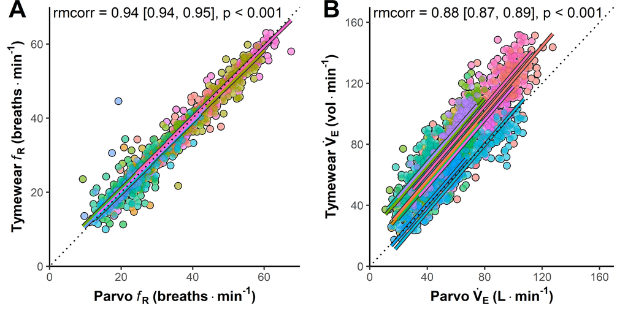

```r
ggarrange(
    tar_read(rmcorr_plot_RR),
    tar_read(rmcorr_plot_VE_excl),
    nrow = 1,
    ncol = 2,
    labels = c("A", "B"),
    vjust = 1,
    font.label = list(size = 24)
)
```

## Figure 3: Agreement

### RR

```r
tar_read(agree_fit_RR)
```

```
#> Bland-Altman Limits of Agreement (LoA)
#> 95% LoA @ 5% Alpha-Level
#> Nested Data
#>
#>     Bias           Bias CI Lower LoA Upper LoA           LoA CI
#>  -0.1563 [-0.3679, 0.0553]    -3.702     3.389 [-3.877, 3.5645]
#>
#> SD of Differences = 1.8088
```

```r
tar_read(agree_log_fit_RR)
```

```
#> Bland-Altman Limits of Agreement (LoA) of the Sympercent Difference (s%)
#> 95% LoA @ 5% Alpha-Level
#> Log-transformed Nested Data
#>
#>     Bias           Bias CI Lower LoA Upper LoA              LoA CI
#>  -0.4292 [-1.1453, 0.2869]    -14.15     13.29 [-14.7489, 13.8905]
#>
#> Coefficient of Variation (%) = 7.0014
```

### VE

- VE is fit with proportional bias, so the untransformed LoA table has one row per evaluation point — bias and limits at the minimum, mean, and maximum of the mean of the two devices
- The log-ratio fit below keeps a single flat bias.

```r
tar_read(agree_fit_VE)
```

```
#> Bland-Altman Limits of Agreement (LoA)
#> 95% LoA @ 5% Alpha-Level
#> Nested Data
#>
#>  Average of Both Methods   Bias            Bias CI Lower LoA Upper LoA
#>                    15.24  7.724 [-7.5607, 23.0085]    -49.55     64.99
#>                    77.05 36.155 [20.9055, 51.4047]    -21.11     93.42
#>                   171.09 79.403  [64.0728, 94.733]     22.13    136.67
#>               LoA CI
#>   [-69.2002, 84.648]
#>  [-40.769, 113.0792]
#>    [2.4788, 156.327]
#>
#> SD of Differences = 29.2197
```

```r
tar_read(agree_log_fit_VE)
```

```
#> Bland-Altman Limits of Agreement (LoA) of the Sympercent Difference (s%)
#> 95% LoA @ 5% Alpha-Level
#> Log-transformed Nested Data
#>
#>   Bias            Bias CI Lower LoA Upper LoA               LoA CI
#>  46.13 [26.5826, 65.6774]    -28.46     120.7 [-53.3934, 145.6535]
#>
#> Coefficient of Variation (%) = 38.056
```

### VE (four participants excluded)

- As above, proportional bias gives one LoA row each at minimum, mean, and maximum; log-ratio keeps a single flat bias.

```r
tar_read(agree_fit_VE_excl)
```

```
#> Bland-Altman Limits of Agreement (LoA)
#> 95% LoA @ 5% Alpha-Level
#> Nested Data
#>
#>  Average of Both Methods   Bias            Bias CI Lower LoA Upper LoA
#>                    17.15  6.067 [-0.9823, 13.1154]   -20.531     32.66
#>                    70.68 18.564 [11.5739, 25.5534]    -8.034     45.16
#>                   135.49 33.693 [26.6161, 40.7703]     7.095     60.29
#>               LoA CI
#>  [-28.2392, 40.3724]
#>  [-15.7421, 52.8694]
#>    [-0.6126, 67.999]
#>
#> SD of Differences = 13.5705
```

**Show figure code**

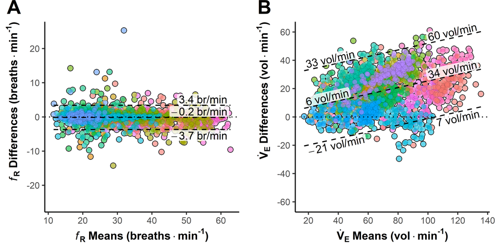

```r
ggarrange(
    tar_read(agree_plot_RR),
    tar_read(agree_plot_VE_excl),
    nrow = 1,
    ncol = 2,
    labels = c("A", "B"),
    vjust = 1,
    font.label = list(size = 24)
)
```

## Figure 4: Effect of cycling position

- Participants alternated between “upright” (UP) and “racing position” (RP): UP — RP — UP — RP — UP
- Four participants excluded for VE only.

**Show figure code**

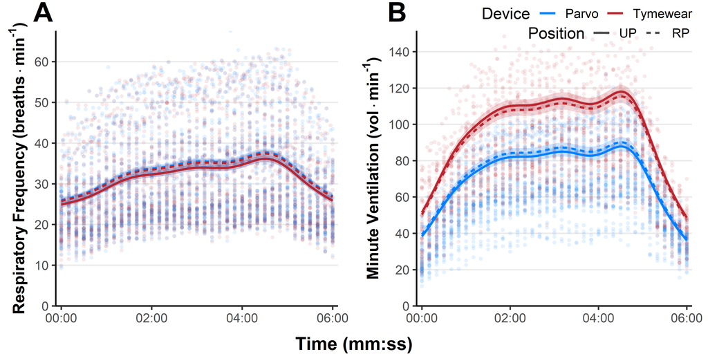

```r
ggarrange(
    tar_read(pred_pos_plot_RR_pos) + rremove("x.title") + rremove("legend"),
    tar_read(pred_pos_plot_VE_pos) + rremove("x.title"),
    nrow = 1,
    ncol = 2,
    # common.legend = TRUE,
    labels = c("A", "B"),
    vjust = 1.1,
    hjust = -1.7,
    font.label = list(size = 24)
) |>
    annotate_figure(
        bottom = text_grob("Time (mm:ss)", size = 16, face = "bold")
    )
```

## Figure 5: Equivalence Testing — Device

### RR

```r
## mixed model of log RR
summary(tar_read(eq_fit_RR)$model)
```

```
#> Linear mixed model fit by REML. t-tests use Satterthwaite's method [
#> lmerModLmerTest]
#> Formula: as.formula(str_glue("log({yvar}) ~ device + time + (1 | id / stage)"))
#>    Data: df_long
#>
#> REML criterion at convergence: -4724.1
#>
#> Scaled residuals:
#>     Min      1Q  Median      3Q     Max
#> -7.9811 -0.4376  0.2115  0.6172  5.4346
#>
#> Random effects:
#>  Groups   Name        Variance Std.Dev.
#>  stage:id (Intercept) 0.005809 0.07621
#>  id       (Intercept) 0.101054 0.31789
#>  Residual             0.023491 0.15327
#> Number of obs: 5520, groups:  stage:id, 75; id, 15
#>
#> Fixed effects:
#>                  Estimate Std. Error         df t value Pr(>|t|)
#> (Intercept)     3.292e+00  8.267e-02  1.407e+01  39.816 7.28e-16 ***
#> deviceTymewear -4.279e-03  4.126e-03  5.443e+03  -1.037      0.3
#> time            4.153e-04  1.942e-05  5.443e+03  21.383  < 2e-16 ***
#> ---
#> Signif. codes:  0 '***' 0.001 '**' 0.01 '*' 0.05 '.' 0.1 ' ' 1
#>
#> Correlation of Fixed Effects:
#>             (Intr) dvcTym
#> deviceTymwr -0.025
#> time        -0.042  0.000
```

```r
## Tymewear vs Parvo mean log-ratio, TOST against ±3%
tar_read(eq_fit_RR)$eq
```

```
#>
#>  Estimate Std. Error     z Pr(>|z|)   S   5.0 %  95.0 % p (NonSup) p (Equiv)
#>  -0.00428    0.00413 -1.04      0.3 1.7 -0.0111 0.00251     <0.001    <0.001
#>
#> Term: device
#> Type: response
#> Comparison: Tymewear - Parvo
```

### VE

```r
## mixed model of log VE
summary(tar_read(eq_fit_VE)$model)
```

```
#> Linear mixed model fit by REML. t-tests use Satterthwaite's method [
#> lmerModLmerTest]
#> Formula: as.formula(str_glue("log({yvar}) ~ device + time + (1 | id / stage)"))
#>    Data: df_long
#>
#> REML criterion at convergence: 4004
#>
#> Scaled residuals:
#>     Min      1Q  Median      3Q     Max
#> -7.2348 -0.4013  0.1565  0.6714  1.9798
#>
#> Random effects:
#>  Groups   Name        Variance Std.Dev.
#>  stage:id (Intercept) 0.002768 0.05261
#>  id       (Intercept) 0.055990 0.23662
#>  Residual             0.117379 0.34261
#> Number of obs: 5520, groups:  stage:id, 75; id, 15
#>
#> Fixed effects:
#>                 Estimate Std. Error        df t value Pr(>|t|)
#> (Intercept)    3.907e+00  6.224e-02 1.461e+01   62.78   <2e-16 ***
#> deviceTymewear 4.600e-01  9.223e-03 5.443e+03   49.87   <2e-16 ***
#> time           5.495e-04  4.342e-05 5.443e+03   12.66   <2e-16 ***
#> ---
#> Signif. codes:  0 '***' 0.001 '**' 0.01 '*' 0.05 '.' 0.1 ' ' 1
#>
#> Correlation of Fixed Effects:
#>             (Intr) dvcTym
#> deviceTymwr -0.074
#> time        -0.126  0.000
```

```r
## Tymewear vs Parvo mean log-ratio, TOST against ±3%
tar_read(eq_fit_VE)$eq
```

```
#>
#>  Estimate Std. Error    z Pr(>|z|)   S 5.0 % 95.0 % p (NonSup) p (Equiv)
#>      0.46    0.00922 49.9   <0.001 Inf 0.445  0.475          1         1
#>
#> Term: device
#> Type: response
#> Comparison: Tymewear - Parvo
```

### VE (four participants excluded)

```r
## mixed model of log VE
summary(tar_read(eq_fit_VE_excl)$model)
```

```
#> Linear mixed model fit by REML. t-tests use Satterthwaite's method [
#> lmerModLmerTest]
#> Formula: as.formula(str_glue("log({yvar}) ~ device + time + (1 | id / stage)"))
#>    Data: df_long
#>
#> REML criterion at convergence: 2021.9
#>
#> Scaled residuals:
#>     Min      1Q  Median      3Q     Max
#> -5.3743 -0.3962  0.2881  0.6605  1.8659
#>
#> Random effects:
#>  Groups   Name        Variance Std.Dev.
#>  stage:id (Intercept) 0.002036 0.04513
#>  id       (Intercept) 0.050463 0.22464
#>  Residual             0.093379 0.30558
#> Number of obs: 4060, groups:  stage:id, 55; id, 11
#>
#> Fixed effects:
#>                 Estimate Std. Error        df t value Pr(>|t|)
#> (Intercept)    3.981e+00  6.882e-02 1.038e+01  57.843 2.26e-14 ***
#> deviceTymewear 2.759e-01  9.592e-03 4.003e+03  28.765  < 2e-16 ***
#> time           3.680e-04  4.502e-05 4.003e+03   8.173 4.00e-16 ***
#> ---
#> Signif. codes:  0 '***' 0.001 '**' 0.01 '*' 0.05 '.' 0.1 ' ' 1
#>
#> Correlation of Fixed Effects:
#>             (Intr) dvcTym
#> deviceTymwr -0.070
#> time        -0.118  0.000
```

```r
## Tymewear vs Parvo mean log-ratio, TOST against ±3%
tar_read(eq_fit_VE_excl)$eq
```

```
#>
#>  Estimate Std. Error    z Pr(>|z|)     S 5.0 % 95.0 % p (NonSup) p (Equiv)
#>     0.276    0.00959 28.8   <0.001 602.1  0.26  0.292          1         1
#>
#> Term: device
#> Type: response
#> Comparison: Tymewear - Parvo
```

## Equivalence Testing — Body Position

- racing versus upright position, with the device effect and its interaction retained in the model.
- Four participants excluded for VE only.

### RR

```r
## mixed model of log RR
summary(tar_read(eq_pos_fit_RR_pos)$model)
```

```
#>
#> Family: gaussian
#> Link function: identity
#>
#> Formula:
#> log(RR) ~ s(time, by = dp, k = 10) + device * position + s(id,
#>     bs = "re")
#>
#> Parametric coefficients:
#>                            Estimate Std. Error t value Pr(>|t|)
#> (Intercept)                3.349718   0.162815  20.574  < 2e-16 ***
#> deviceTymewear            -0.001602   0.004600  -0.348    0.728
#> positionRP                 0.041962   0.005143   8.159 4.17e-16 ***
#> deviceTymewear:positionRP -0.006586   0.007274  -0.905    0.365
#> ---
#> Signif. codes:  0 '***' 0.001 '**' 0.01 '*' 0.05 '.' 0.1 ' ' 1
#>
#> Approximate significance of smooth terms:
#>                          edf Ref.df       F p-value
#> s(time):dpParvo.UP     8.247  8.844  136.13  <2e-16 ***
#> s(time):dpTymewear.UP  8.239  8.841  127.71  <2e-16 ***
#> s(time):dpParvo.RP     8.081  8.774   82.25  <2e-16 ***
#> s(time):dpTymewear.RP  8.248  8.845   89.58  <2e-16 ***
#> s(id)                 13.998 15.000 1976.05  <2e-16 ***
#> ---
#> Signif. codes:  0 '***' 0.001 '**' 0.01 '*' 0.05 '.' 0.1 ' ' 1
#>
#> R-sq.(adj) =   0.86   Deviance explained = 86.1%
#> GCV = 0.017685  Scale est. = 0.017522  n = 5520
```

```r
## racing vs upright mean log-ratio, TOST against ±3%
tar_read(eq_pos_fit_RR_pos)$eq
```

```
#>
#>            Hypothesis Estimate Std. Error      z Pr(>|z|)   S   5.0 %  95.0 %
#>  (Tymewear) - (Parvo) -0.00659    0.00727 -0.905    0.365 1.5 -0.0186 0.00538
#>  p (NonSup) p (Equiv)
#>      <0.001    <0.001
#>
#> Type: response
```

### VE

```r
## mixed model of log VE
summary(tar_read(eq_pos_fit_VE_pos)$model)
```

```
#>
#> Family: gaussian
#> Link function: identity
#>
#> Formula:
#> log(VE) ~ s(time, by = dp, k = 10) + device * position + s(id,
#>     bs = "re")
#>
#> Parametric coefficients:
#>                            Estimate Std. Error t value Pr(>|t|)
#> (Intercept)                4.036318   0.057492  70.206  < 2e-16 ***
#> deviceTymewear             0.295468   0.006416  46.053  < 2e-16 ***
#> positionRP                 0.026430   0.007173   3.685 0.000232 ***
#> deviceTymewear:positionRP -0.048891   0.010144  -4.820 1.49e-06 ***
#> ---
#> Signif. codes:  0 '***' 0.001 '**' 0.01 '*' 0.05 '.' 0.1 ' ' 1
#>
#> Approximate significance of smooth terms:
#>                         edf Ref.df     F p-value
#> s(time):dpParvo.UP    8.588  8.951 438.4  <2e-16 ***
#> s(time):dpTymewear.UP 8.603  8.955 349.9  <2e-16 ***
#> s(time):dpParvo.RP    8.337  8.878 267.1  <2e-16 ***
#> s(time):dpTymewear.RP 8.595  8.953 234.6  <2e-16 ***
#> s(id)                 9.981 10.000 728.0  <2e-16 ***
#> ---
#> Signif. codes:  0 '***' 0.001 '**' 0.01 '*' 0.05 '.' 0.1 ' ' 1
#>
#> R-sq.(adj) =  0.845   Deviance explained = 84.7%
#> GCV = 0.025368  Scale est. = 0.025068  n = 4060
```

```r
## racing vs upright mean log-ratio, TOST against ±3%
tar_read(eq_pos_fit_VE_pos)$eq
```

```
#>
#>            Hypothesis Estimate Std. Error     z Pr(>|z|)    S   5.0 %  95.0 %
#>  (Tymewear) - (Parvo)  -0.0489     0.0101 -4.82   <0.001 19.4 -0.0656 -0.0322
#>  p (NonSup) p (Equiv)
#>      <0.001     0.972
#>
#> Type: response
```

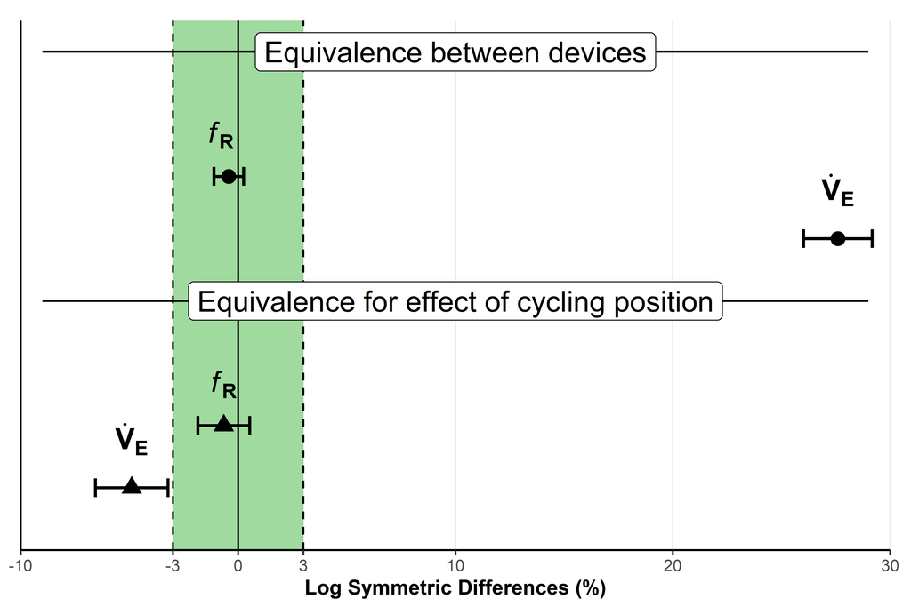

```r
eq_RR <- tar_read(eq_fit_RR)$eq
eq_VE <- tar_read(eq_fit_VE_excl)$eq
eq_RR_pos <- tar_read(eq_pos_fit_RR_pos)$eq
eq_VE_pos <- tar_read(eq_pos_fit_VE_pos)$eq

## estimates, CIs and point styling for device and body-position equivalence
obs_df <- bind_rows(eq_RR, eq_VE, eq_RR_pos, eq_VE_pos) |>
    mutate(
        across(c(estimate, conf.low, conf.high), \(.x) .x * 100),
        y = c(3, 2.5, 1, 0.5),
        label = rep(
            c("bold(italic('f')['R'])", "bold(dot(V)['E'])"),
            2
        ),
        shape = c(19, 19, 17, 17),
        size = c(4, 4, 4.5, 4.5),
        hjust = c(0.8, 0.5, 0.5, 0.5),
    )

ggplot(obs_df, aes(x = estimate, y = y)) +
    theme(
        legend.position = "none",
        axis.ticks.y = element_blank(),
        axis.text.y = element_blank(),
        axis.title.y = element_blank(),
        panel.grid.major.x = element_line(colour = "grey90", linewidth = 0.5),
        plot.margin = margin(5, 5, 2, 5, unit = "mm"),
    ) +
    coord_cartesian(xlim = c(-10, 30), ylim = c(0, 4.25)) +
    scale_x_continuous(
        name = "Log Symmetric Differences (%)",
        breaks = c(-10, -3, 3, seq(0, 30, 10)),
        expand = expansion(0),
    ) +
    scale_y_continuous(expand = expansion(0)) +
    annotate(
        "rect",
        xmin = -3,
        xmax = 3,
        ymin = -Inf,
        ymax = Inf,
        fill = "#42B540FF",
        alpha = 0.5,
    ) +
    geom_vline(
        xintercept = c(-3, 0, 3),
        linetype = c("dashed", "solid", "dashed")
    ) +
    geom_errorbar(
        aes(xmin = conf.low, xmax = conf.high),
        linewidth = 1,
        width = 0.15
    ) +
    geom_point(shape = obs_df$shape, size = obs_df$size) +
    geom_text(
        aes(label = label, hjust = hjust),
        vjust = -1,
        size = 7,
        parse = TRUE
    ) +
    annotate(
        "segment",
        x = -9,
        xend = 29,
        y = c(4, 2),
        linewidth = 0.7
    ) +
    annotate(
        "label",
        x = 10,
        y = c(4, 2),
        size = 7,
        label = c(
            "Equivalence between devices",
            "Equivalence for effect of cycling position"
        ),
    )
```